# Final Project 4

Siyu Zhai

2025-04-10

# Introduction

# Analysis Objectives

Based on this dataset, some of my expectations are like to find out:  
1. the descriptive statistics of personal exposure and symptom information for each specific variable;  
2. the relationship between specific exposure and lung cancer, what are the potential risk factors for lung cancer;  
3. will gender or age have an impact on contracting lung cancer;  
4. the prediction logit model to forecast the probability of contracting lung cancer;  
5. how to treat lung cancer best;  
6. any corresponding suggestion to prevent lung cancer, etc.

Particularly in this time, I will complete objective 1, and the rest of model establishment will be done in the subsequent projects.

# Collected Data

Here is loading data code and dataset is display below with the first ten rows.

```r
absolute_file_path <- here::here("data/cancer_patient_data_set_copy.csv" )
df_sorted <- read.csv(absolute_file_path, header = TRUE)
#print(absolute_file_path)
```

| Patient.Id | Gender | Age | Air.Pollution | Alcohol.use | Dust.Allergy | OccuPational.Hazards | Genetic.Risk | chronic.Lung.Disease | Balanced.Diet | Obesity | Smoking | Passive.Smoker | Chest.Pain | Coughing.of.Blood | Fatigue | Weight.Loss | Shortness.of.Breath | Wheezing | Swallowing.Difficulty | Clubbing.of.Finger.Nails | Frequent.Cold | Dry.Cough | Snoring | Level |
| --- | --- | --- | --- | --- | --- | --- | --- | --- | --- | --- | --- | --- | --- | --- | --- | --- | --- | --- | --- | --- | --- | --- | --- | --- |
| 1 | Female | 33 | 2 | 4 | 5 | 4 | 3 | 2 | 2 | 4 | 3 | 2 | 2 | 4 | 3 | 4 | 2 | 2 | 3 | 1 | 2 | 3 | 4 | Low |
| 2 | Female | 17 | 3 | 1 | 5 | 3 | 4 | 2 | 2 | 2 | 2 | 4 | 2 | 3 | 1 | 3 | 7 | 8 | 6 | 2 | 1 | 7 | 2 | Medium |
| 3 | Female | 35 | 4 | 5 | 6 | 5 | 5 | 4 | 6 | 7 | 2 | 3 | 4 | 8 | 8 | 7 | 9 | 2 | 1 | 4 | 6 | 7 | 2 | High |
| 4 | Female | 37 | 7 | 7 | 7 | 7 | 6 | 7 | 7 | 7 | 7 | 7 | 7 | 8 | 4 | 2 | 3 | 1 | 4 | 5 | 6 | 7 | 5 | High |
| 5 | Female | 46 | 6 | 8 | 7 | 7 | 7 | 6 | 7 | 7 | 8 | 7 | 7 | 9 | 3 | 2 | 4 | 1 | 4 | 2 | 4 | 2 | 3 | High |
| 6 | Female | 35 | 4 | 5 | 6 | 5 | 5 | 4 | 6 | 7 | 2 | 3 | 4 | 8 | 8 | 7 | 9 | 2 | 1 | 4 | 6 | 7 | 2 | High |
| 7 | Male | 52 | 2 | 4 | 5 | 4 | 3 | 2 | 2 | 4 | 3 | 2 | 2 | 4 | 3 | 4 | 2 | 2 | 3 | 1 | 2 | 3 | 4 | Low |
| 8 | Male | 28 | 3 | 1 | 4 | 3 | 2 | 3 | 4 | 3 | 1 | 4 | 3 | 1 | 3 | 2 | 2 | 4 | 2 | 2 | 3 | 4 | 3 | Low |
| 9 | Male | 35 | 4 | 5 | 6 | 5 | 6 | 5 | 5 | 5 | 6 | 6 | 6 | 5 | 1 | 4 | 3 | 2 | 4 | 6 | 2 | 4 | 1 | Medium |
| 10 | Female | 46 | 2 | 3 | 4 | 2 | 4 | 3 | 3 | 3 | 2 | 3 | 4 | 4 | 1 | 2 | 4 | 6 | 5 | 4 | 2 | 1 | 5 | Medium |

# Descriptive Analysis

To better visualize dataset for understanding and subsequent analyzing, tabular analysis and graphic analysis are included in this part.

### Tabular analysis

To clearly define each variable, a table of variables within dataset, their types, and descriptions is generated.

```
##                    Variable                  Type
## 1                patient.id               Integer
## 2                    gender Binary (Female, Male)
## 3                       age               Integer
## 4             air pollution   Categorical (1 - 9)
## 5               alcohol use   Categorical (1 - 9)
## 6              dust allergy   Categorical (1 - 9)
## 7      occupational hazards   Categorical (1 - 9)
## 8              genetic risk   Categorical (1 - 9)
## 9      chronic lung disease   Categorical (1 - 9)
## 10            balanced diet   Categorical (1 - 9)
## 11                  obesity   Categorical (1 - 9)
## 12                  smoking   Categorical (1 - 9)
## 13           passive smoker   Categorical (1 - 9)
## 14               chest pain   Categorical (1 - 9)
```

[output cut: 29 more lines]

The descriptive statistics (minimum, first quantile, median, third quantile, maximum) of all scalar variables are listed in the table below.

```
##                          Min First Quantile Median Third Quantile Max
## Age                       14          27.75     36             45  73
## Air.Pollution              1           2.00      3              6   8
## Alcohol.use                1           2.00      5              7   8
## Dust.Allergy               1           4.00      6              7   8
## OccuPational.Hazards       1           3.00      5              7   8
## Genetic.Risk               1           2.00      5              7   7
## chronic.Lung.Disease       1           3.00      4              6   7
## Balanced.Diet              1           2.00      4              7   7
## Obesity                    1           3.00      4              7   7
## Smoking                    1           2.00      3              7   8
## Passive.Smoker             1           2.00      4              7   8
## Chest.Pain                 1           2.00      4              7   9
## Coughing.of.Blood          1           3.00      4              7   9
## Fatigue                    1           2.00      3              5   9
## Weight.Loss                1           2.00      3              6   8
## Shortness.of.Breath        1           2.00      4              6   9
## Wheezing                   1           2.00      4              5   8
## Swallowing.Difficulty      1           2.00      4              5   8
## Clubbing.of.Finger.Nails   1           2.00      4              5   9
## Frequent.Cold              1           2.00      3              5   7
## Dry.Cough                  1           2.00      4              6   7
## Snoring                    1           2.00      3              4   7
```

Since there are enormous variables, I only select smoking from the exposure variable and shortness of breath from the symptom variable to compare the proportions of people of different degrees under genders.

| **Characteristic** | **Overall** N = 1,000<sup>1</sup> | **Table 3. Proportion of People of Multiple Smoking Levels by Gender** **Female** N = 598<sup>1</sup> | **Table 3. Proportion of People of Multiple Smoking Levels by Gender** **Male** N = 402<sup>1</sup> |
| --- | --- | --- | --- |
| Age | 36 (28, 45) | 37 (32, 46) | 35 (26, 39) |
| Smoking |  |  |  |
| 1 | 181 (18%) | 102 (17%) | 79 (20%) |
| 2 | 222 (22%) | 102 (17%) | 120 (30%) |
| 3 | 172 (17%) | 79 (13%) | 93 (23%) |
| 4 | 59 (5.9%) | 49 (8.2%) | 10 (2.5%) |
| 5 | 10 (1.0%) | 10 (1.7%) | 0 (0%) |
| 6 | 60 (6.0%) | 28 (4.7%) | 32 (8.0%) |
| 7 | 207 (21%) | 167 (28%) | 40 (10.0%) |
| 8 | 89 (8.9%) | 61 (10%) | 28 (7.0%) |

<sup>1</sup> Median (Q1, Q3); n (%)

| **Characteristic** | **Overall** N = 1,000<sup>1</sup> | **Table 4. Proportion of People of Multiple Shortness of Breath Levels by Gender** **Female** N = 598<sup>1</sup> | **Table 4. Proportion of People of Multiple Shortness of Breath Levels by Gender** **Male** N = 402<sup>1</sup> |
| --- | --- | --- | --- |
| Age | 36 (28, 45) | 37 (32, 46) | 35 (26, 39) |
| Shortness of Breath |  |  |  |
| 1 | 80 (8.0%) | 30 (5.0%) | 50 (12%) |
| 2 | 243 (24%) | 151 (25%) | 92 (23%) |
| 3 | 140 (14%) | 84 (14%) | 56 (14%) |
| 4 | 90 (9.0%) | 41 (6.9%) | 49 (12%) |
| 5 | 87 (8.7%) | 68 (11%) | 19 (4.7%) |
| 6 | 201 (20%) | 133 (22%) | 68 (17%) |
| 7 | 89 (8.9%) | 59 (9.9%) | 30 (7.5%) |
| 9 | 70 (7.0%) | 32 (5.4%) | 38 (9.5%) |

<sup>1</sup> Median (Q1, Q3); n (%)

### Graphical analysis

Firstly, a heatmap is generated to imply the correlation between variables prior to building the quantitative model. As shown in this table, there are no correlation coefficients within the range of [-1, -0.4). In the heatmap, the intensity of the tile color indicates the strength of the correlation, with darker shades representing stronger correlations between each pair of variables.

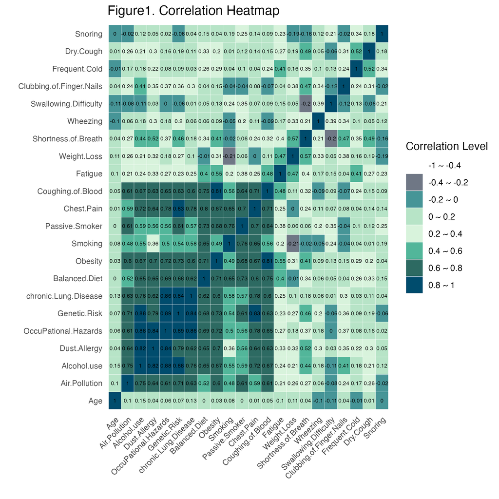

Secondly, two stacked bar charts are plotted with the Figure2 is about exposure and Figure3 is about body symptom. From the figures we could find the distribution of level of exposure and intensity of body symptom.

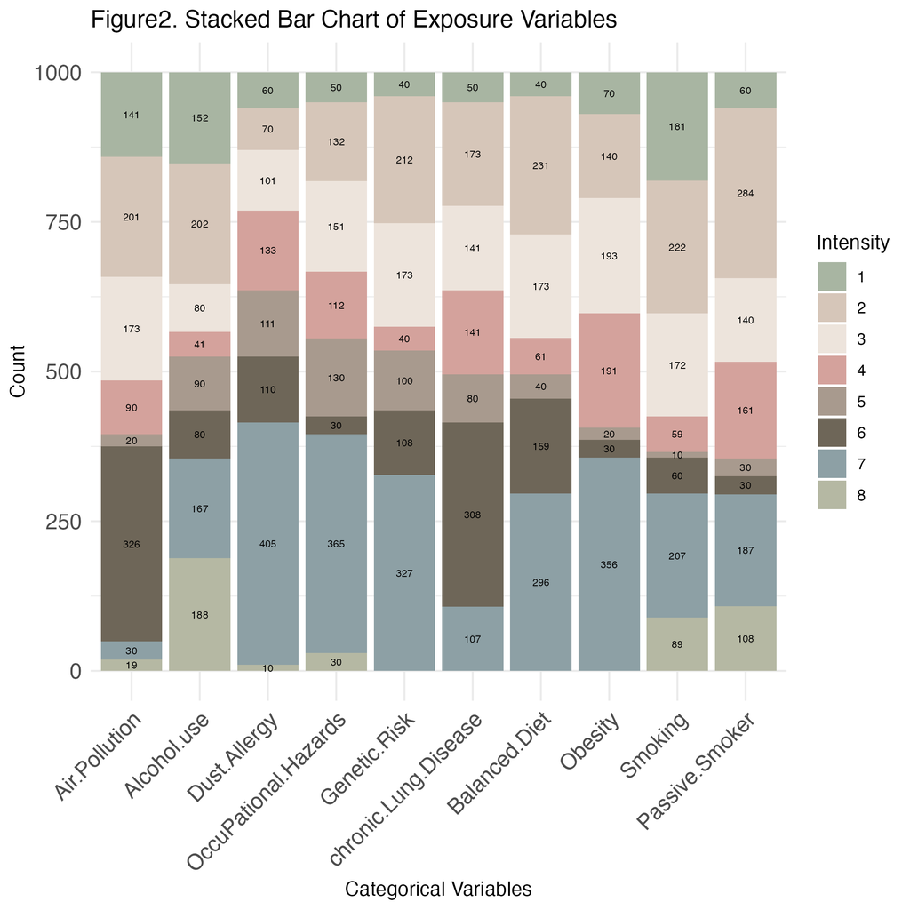

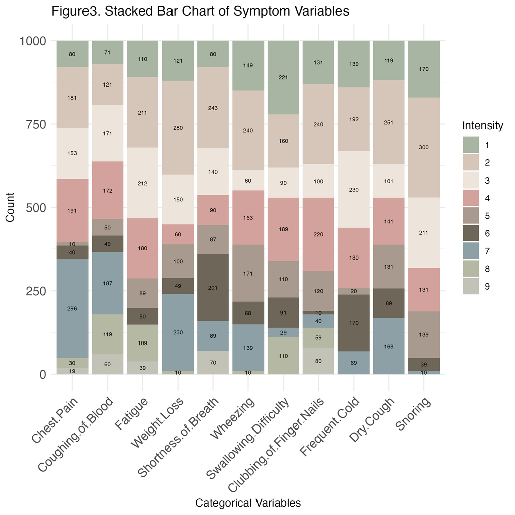